# ProjetAD

### ii :

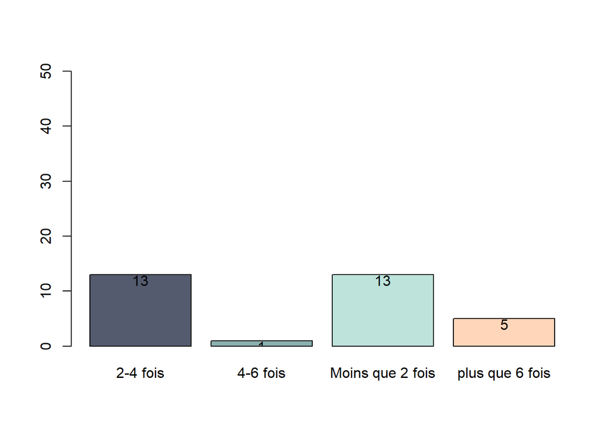

```r
colors=c("#555b6e","#89b0ae","#bee3db","#ffd6ba")
b <- barplot(table(ques$`3-Combien de fois par semaine regardez-vous les films/séries?`),col=colors,ylim=c(0,50))
text(b[,1],table(ques$`3-Combien de fois par semaine regardez-vous les films/séries?`)-1,table(ques$`3-Combien de fois par semaine regardez-vous les films/séries?`))
```

Interprétation: on remarque que la majorité des repondants regarde un films au plus fois dans la semaine

## 3/- Analyse en Composantes Principales :

Pour avoir les principaux raisons pour regarder un film,nous avouns effectuer une ACP sur 11 variables quantitatives (Presse spécialisée, Presse généraliste , Site Internet , Emission télévisuelle, Bande annonce, Conseils d’un ami, Conseils d’un membre de la famille, Critiques de films ,Bandes Annonces,L’affiche ,Le hasard) Cette méthode synthetise toutes ces informations en seulement quelques nouvelles variables appelées composantes principales( une combinaison linéaire des variables d’origine. Elle regroupe également les individus ayant les meme raisons de regarder les films.